# TpitReport

W. McDonald

2/24/2019

## Goal

The goal of this document is to reproducibly import, wrangle and analyse the full pituitary adenoma tissue microarray dataset, including all immunostains up to *Tpit*. *CAM5.2* staining pattern is included, as a relevant categorical variable. Otherwise, IHC staining extant and intensity are reported as Allred scores as previously published.

This analysis will rely on the tools of the tidyverse, when possible.

## Data import, wrangling.

```r
library(tidyverse)
patma <- read_csv("data/TpitAddedDx")
newClass <- patma %>%
  count(newDx, sort = TRUE)
newClass
```

```
## # A tibble: 13 x 2
##    newDx       n
##    <chr>   <int>
##  1 GON        81
##  2 ACTH       26
##  3 PRL        14
##  4 NULL       11
##  5 GH+         5
##  6 PRL+        5
##  7 GH          4
##  8 PlurGH      3
##  9 UNK         3
## 10 PlurGH+     2
## 11 PIT1        1
## 12 PLUR        1
## 13 TSH+        1
```

```r
sum(newClass$n)
```

```
## [1] 157
```

```r
oldClass <- patma %>%
  count(Dx, sort = TRUE)
oldClass
```

```
## # A tibble: 13 x 2
##    Dx          n
##    <chr>   <int>
##  1 GON        81
##  2 NULL       18
##  3 ACTH       15
##  4 PRL        14
##  5 UNK         6
##  6 GH+         5
##  7 PRL+        5
##  8 GH          4
##  9 PlurGH      3
## 10 PlurGH+     2
## 11 TSH+        2
## 12 PIT1        1
## 13 PLUR        1
```

```r
sum(oldClass$n)
```

```
## [1] 157
```

```r
tsh <- patma %>%
  group_by(newDx) %>%
  summarize(mean(TSHMedian, na.rm = TRUE))

tsh
```

```
## # A tibble: 13 x 2
##    newDx   `mean(TSHMedian, na.rm = TRUE)`
##    <chr>                             <dbl>
##  1 ACTH                              0.385
##  2 GH                                0
##  3 GH+                               2.6
##  4 GON                               0
##  5 NULL                              0
##  6 PIT1                              4.5
##  7 PLUR                              0
##  8 PlurGH                            1.67
##  9 PlurGH+                           2.5
## 10 PRL                               0
## 11 PRL+                              0.8
## 12 TSH+                              8
## 13 UNK                               4.17
```

## IHC by diagnosis scatter plots

A basic understanding of the staining patterns is an important first step.

Multiple ways to display these in a grid. The gridExtra package is pretty simple. See [this useful vignette](https://cran.r-project.org/web/packages/egg/vignettes/Ecosystem.html).

```r
library(gridExtra)
```

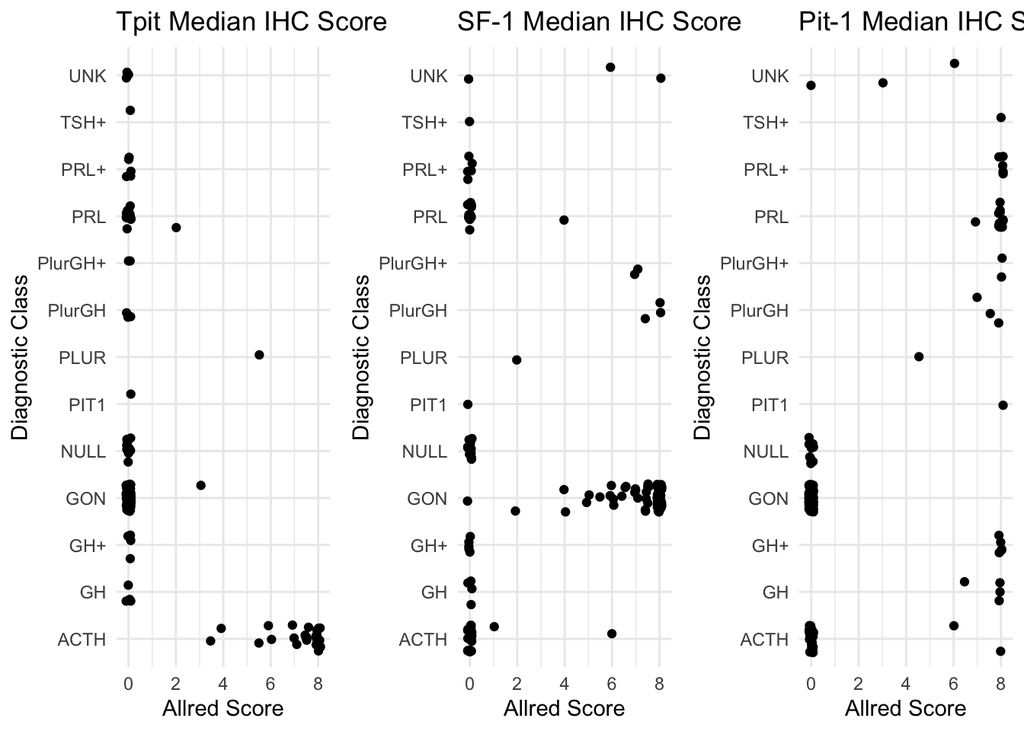

```r
p<-ggplot(patma, aes(newDx, TPITMedian))
p1 <- p + geom_point(position=position_jitter(width=0.3, height=0.1)) +
  theme_minimal() +
  coord_flip() +
  labs(x="Diagnostic Class") +
  labs(y="Allred Score") +
  labs(title="Tpit Median IHC Score")

p<-ggplot(patma, aes(newDx, SF1Median))
p2 <- p + geom_point(position=position_jitter(width=0.3, height=0.1)) +
  theme_minimal() +
  coord_flip() +
  labs(x="Diagnostic Class") +
  labs(y="Allred Score") +
  labs(title="SF-1 Median IHC Score")

p<-ggplot(patma, aes(newDx, Pit1Median))
p3 <- p + geom_point(position=position_jitter(width=0.3, height=0.1)) +
  theme_minimal() +
  coord_flip() +
  labs(x="Diagnostic Class") +
  labs(y="Allred Score") +
  labs(title="Pit-1 Median IHC Score")

grid.arrange(p1, p2, p3, nrow = 1)
```

## Correlation matrix and p values for the correlations

Beyond the R help documentation for cor(), I like the visualizations from [this site that uses corrplot](http://www.sthda.com/english/wiki/visualize-correlation-matrix-using-correlogram)

The package Hmisc is used to generate p-values for the correlation matrix.

```r
library(corrplot)
patma %>%
  select(SF1Median, Pit1Median, TPITMedian, PRLMedian, GHMedian, TSHMedian, LHMedian, FSHMedian, ACTHMedian) %>%
  cor(y = NULL, use = "complete.obs", method = "pearson") %>%
  round(2)
```

```
##            SF1Median Pit1Median TPITMedian PRLMedian GHMedian TSHMedian
## SF1Median       1.00      -0.44      -0.46     -0.43    -0.19     -0.16
## Pit1Median     -0.44       1.00      -0.19      0.78     0.65      0.33
## TPITMedian     -0.46      -0.19       1.00     -0.14    -0.15     -0.05
## PRLMedian      -0.43       0.78      -0.14      1.00     0.23      0.04
## GHMedian       -0.19       0.65      -0.15      0.23     1.00      0.43
## TSHMedian      -0.16       0.33      -0.05      0.04     0.43      1.00
## LHMedian        0.43      -0.23      -0.20     -0.21    -0.16     -0.11
## FSHMedian       0.38      -0.27      -0.21     -0.22    -0.20     -0.12
## ACTHMedian     -0.32      -0.15       0.77     -0.10    -0.12     -0.06
##            LHMedian FSHMedian ACTHMedian
## SF1Median      0.43      0.38      -0.32
## Pit1Median    -0.23     -0.27      -0.15
## TPITMedian    -0.20     -0.21       0.77
## PRLMedian     -0.21     -0.22      -0.10
## GHMedian      -0.16     -0.20      -0.12
## TSHMedian     -0.11     -0.12      -0.06
## LHMedian       1.00      0.45      -0.11
## FSHMedian      0.45      1.00      -0.17
## ACTHMedian    -0.11     -0.17       1.00
```

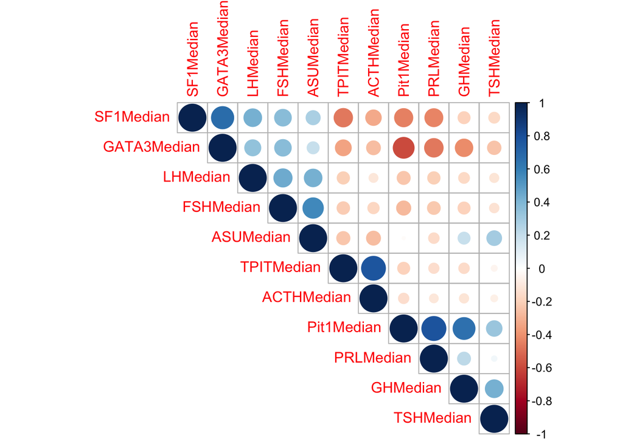

```r
M <- patma %>%
  select(SF1Median, Pit1Median, TPITMedian, PRLMedian, GHMedian, TSHMedian, LHMedian, FSHMedian, ACTHMedian, ASUMedian, GATA3Median) %>%
  cor(y = NULL, use = "complete.obs", method = "pearson")

corrplot(M, type = "upper", order = "hclust")
```

```r
# mat : is a matrix of data (function by Alboukadel Kassambara
#PhD, see his webpage, cited above)
# ... : further arguments to pass to the native R cor.test function
cor.mtest <- function(mat, ...) {
    mat <- as.matrix(mat)
    n <- ncol(mat)
    p.mat<- matrix(NA, n, n)
    diag(p.mat) <- 0
    for (i in 1:(n - 1)) {
        for (j in (i + 1):n) {
            tmp <- cor.test(mat[, i], mat[, j], ...)
            p.mat[i, j] <- p.mat[j, i] <- tmp$p.value
        }
    }
  colnames(p.mat) <- rownames(p.mat) <- colnames(mat)
  p.mat
}
# matrix of the p-value of the correlation
p.mat <- cor.mtest(M)
head(p.mat[, 1:5])
```

```
##             SF1Median   Pit1Median TPITMedian    PRLMedian    GHMedian
## SF1Median  0.00000000 1.244999e-02 0.04690339 1.215511e-02 0.082497446
## Pit1Median 0.01244999 0.000000e+00 0.81402483 2.717609e-05 0.000527063
## TPITMedian 0.04690339 8.140248e-01 0.00000000 9.299552e-01 0.674597810
## PRLMedian  0.01215511 2.717609e-05 0.92995523 0.000000e+00 0.032644290
## GHMedian   0.08249745 5.270630e-04 0.67459781 3.264429e-02 0.000000000
## TSHMedian  0.18900787 5.343649e-02 0.83886186 2.906309e-01 0.008559581
```

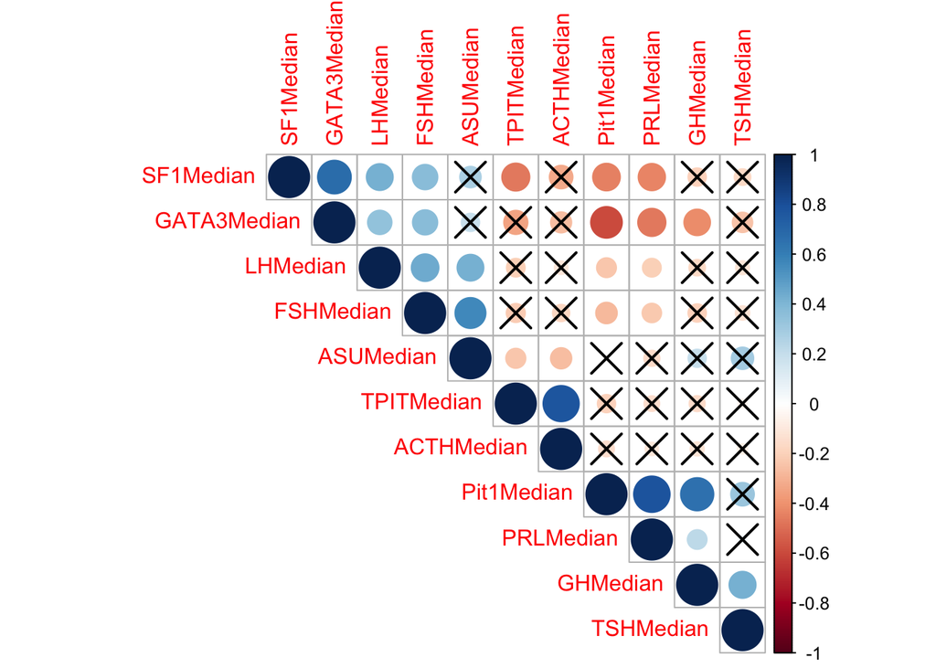

```r
# Specialized the insignificant value according to the significant level: this crosses out insig. values
corrplot(M, type="upper", order="hclust",
         p.mat = p.mat, sig.level = 0.05)
```

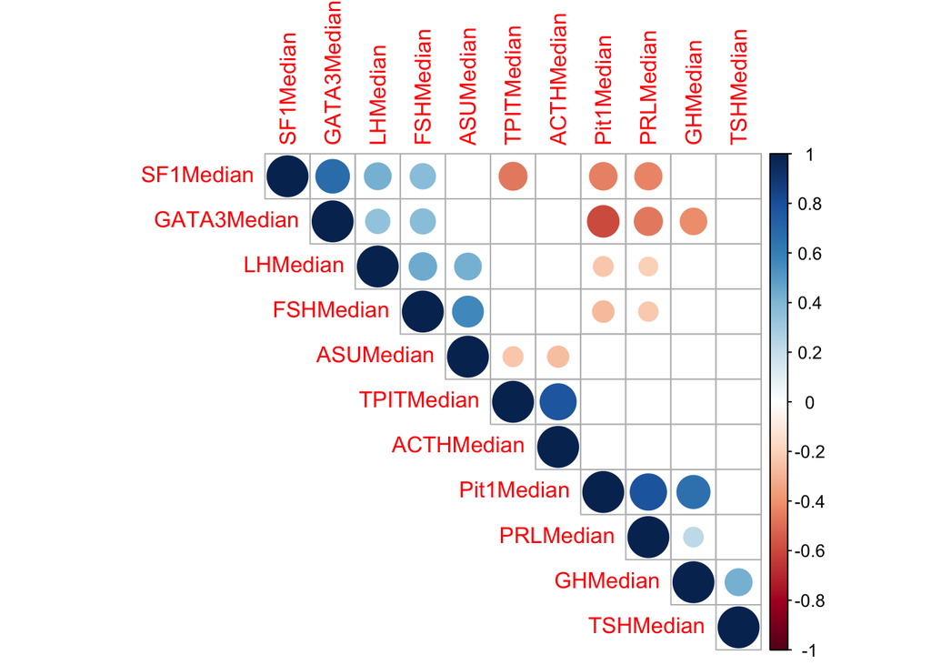

```r
# Leave blank on no significant coefficient
corrplot(M, type="upper", order="hclust",
         p.mat = p.mat, sig.level = 0.05, insig = "blank")
```

```r
# Another way to get p-values manually is to use the Hmisc package:
library(Hmisc)
pvalues <- patma %>%
  select(SF1Median, Pit1Median, TPITMedian, PRLMedian, GHMedian, TSHMedian, LHMedian, FSHMedian, ACTHMedian, ASUMedian, GATA3Median) %>%
  cor(y = NULL, use = "complete.obs", method = "pearson") %>%
  as.matrix() %>%
  rcorr()

pvalues
```

```
##             SF1Median Pit1Median TPITMedian PRLMedian GHMedian TSHMedian
## SF1Median        1.00      -0.72      -0.61     -0.72    -0.55     -0.43
## Pit1Median      -0.72       1.00      -0.08      0.93     0.87      0.60
## TPITMedian      -0.61      -0.08       1.00     -0.03    -0.14     -0.07
## PRLMedian       -0.72       0.93      -0.03      1.00     0.64      0.35
## GHMedian        -0.55       0.87      -0.14      0.64     1.00      0.74
## TSHMedian       -0.43       0.60      -0.07      0.35     0.74      1.00
## LHMedian         0.80      -0.64      -0.46     -0.61    -0.54     -0.44
## FSHMedian        0.77      -0.64      -0.47     -0.61    -0.54     -0.40
## ACTHMedian      -0.55      -0.11       0.97     -0.05    -0.18     -0.14
## ASUMedian        0.58      -0.25      -0.60     -0.39    -0.02      0.15
## GATA3Median      0.94      -0.83      -0.47     -0.78    -0.71     -0.53
##             LHMedian FSHMedian ACTHMedian ASUMedian GATA3Median
## SF1Median       0.80      0.77      -0.55      0.58        0.94
## Pit1Median     -0.64     -0.64      -0.11     -0.25       -0.83
## TPITMedian     -0.46     -0.47       0.97     -0.60       -0.47
## PRLMedian      -0.61     -0.61      -0.05     -0.39       -0.78
## GHMedian       -0.54     -0.54      -0.18     -0.02       -0.71
## TSHMedian      -0.44     -0.40      -0.14      0.15       -0.53
## LHMedian        1.00      0.82      -0.42      0.65        0.77
## FSHMedian       0.82      1.00      -0.46      0.76        0.77
## ACTHMedian     -0.42     -0.46       1.00     -0.64       -0.42
## ASUMedian       0.65      0.76      -0.64      1.00        0.49
## GATA3Median     0.77      0.77      -0.42      0.49        1.00
##
## n= 11
##
##
## P
##             SF1Median Pit1Median TPITMedian PRLMedian GHMedian TSHMedian
## SF1Median             0.0124     0.0469     0.0122    0.0825   0.1890
## Pit1Median  0.0124               0.8140     0.0000    0.0005   0.0534
## TPITMedian  0.0469    0.8140                0.9300    0.6746   0.8389
## PRLMedian   0.0122    0.0000     0.9300               0.0326   0.2906
## GHMedian    0.0825    0.0005     0.6746     0.0326             0.0086
## TSHMedian   0.1890    0.0534     0.8389     0.2906    0.0086
## LHMedian    0.0032    0.0357     0.1519     0.0476    0.0856   0.1794
## FSHMedian   0.0051    0.0356     0.1431     0.0480    0.0880   0.2174
## ACTHMedian  0.0771    0.7389     0.0000     0.8798    0.5874   0.6857
## ASUMedian   0.0630    0.4527     0.0500     0.2396    0.9485   0.6596
## GATA3Median 0.0000    0.0016     0.1480     0.0049    0.0147   0.0921
##             LHMedian FSHMedian ACTHMedian ASUMedian GATA3Median
## SF1Median   0.0032   0.0051    0.0771     0.0630    0.0000
## Pit1Median  0.0357   0.0356    0.7389     0.4527    0.0016
## TPITMedian  0.1519   0.1431    0.0000     0.0500    0.1480
## PRLMedian   0.0476   0.0480    0.8798     0.2396    0.0049
## GHMedian    0.0856   0.0880    0.5874     0.9485    0.0147
## TSHMedian   0.1794   0.2174    0.6857     0.6596    0.0921
## LHMedian             0.0021    0.1993     0.0290    0.0057
## FSHMedian   0.0021             0.1530     0.0061    0.0054
## ACTHMedian  0.1993   0.1530               0.0326    0.1981
## ASUMedian   0.0290   0.0061    0.0326               0.1300
## GATA3Median 0.0057   0.0054    0.1981     0.1300
```

## Hierarchical clustering

Note that the hierarchical clustering profits from name transparency when producing the final plot. The first bits of code make an object that has lost newDx and CaseID in favor of a row name that bears a combination of the two.

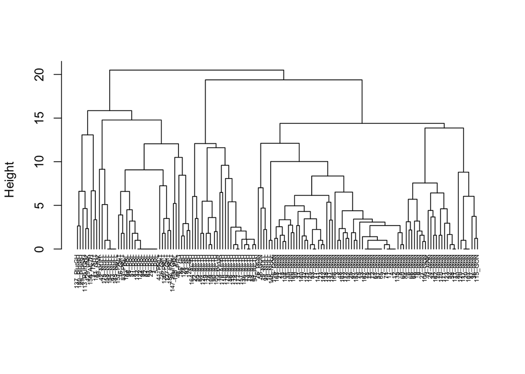

```r
rowsAssigned <- patma %>%
  unite("RowNames", c("CaseID", "newDx")) %>%
  column_to_rownames(var = "RowNames")

df <- rowsAssigned %>%
  select(SF1Median, Pit1Median, TPITMedian, PRLMedian, GHMedian, TSHMedian, LHMedian, FSHMedian, ACTHMedian, ASUMedian, GATA3Median) %>%
  na.omit()

d <- dist(df, method = "euclidean")

hc1 <- hclust(d, method = "complete")

plot(hc1,
     main = "", # As an alternative: main = "Hierarchical Clustering",
     xlab = "",
     sub = "",
     cex.sub = 1.5,
     cex = 0.5,
     #      cex.main = 2, #this doesn't matter since the label is supressed in line 100 with main = ""
     pty = "m",
     hang = -2)
```

Two things are recommended when performing K-means clustering: assign a large nstart and using the setseed() function

```r
set.seed(2019)
rowsAssigned <- patma %>%
  unite("RowNames", c("CaseID", "newDx")) %>%
  column_to_rownames(var = "RowNames")

km6 <- rowsAssigned %>%
  select(SF1Median, Pit1Median, TPITMedian, PRLMedian, GHMedian, TSHMedian, LHMedian, FSHMedian, ACTHMedian) %>%
  na.omit() %>%
  kmeans(6,nstart=20)

km6
```

```
## K-means clustering with 6 clusters of sizes 26, 21, 14, 49, 24, 14
##
## Cluster means:
##   SF1Median Pit1Median TPITMedian  PRLMedian   GHMedian  TSHMedian
## 1 7.6730769  0.1153846 0.00000000 0.00000000 0.00000000 0.00000000
## 2 0.1904762  7.9523810 0.09523810 7.26190476 1.54761905 0.19047619
## 3 0.1428571  0.0000000 0.00000000 0.00000000 0.25000000 0.57142857
## 4 7.4285714  0.0000000 0.06122449 0.04081633 0.03061224 0.00000000
## 5 0.3750000  0.4375000 7.22916667 0.27083333 0.14583333 0.08333333
## 6 3.1071429  7.6428571 0.25000000 1.17857143 5.21428571 2.92857143
##    LHMedian FSHMedian ACTHMedian
## 1 2.0384615 4.0961538  0.0000000
## 2 0.0000000 0.0000000  0.0952381
## 3 0.0000000 0.6428571  0.0000000
## 4 0.6632653 0.1530612  0.1938776
## 5 0.0000000 0.0000000  4.7500000
## 6 0.1071429 0.0000000  0.0000000
##
## Clustering vector:
##       1_PRL       2_GON       3_GON       4_GON       5_PRL       6_GON
##           2           4           4           4           2           1
##      7_TSH+       8_GON       9_GON     10_NULL      11_UNK      12_GON
##           6           4           1           3           1           4
##     14_PLUR     15_NULL      16_GH+      17_GON      18_GON      19_GON
##           5           3           2           4           4           1
##      20_GON      21_GON     22_ACTH      23_GON      24_GON      25_GON
##           4           1           5           4           1           4
##      26_GH+      27_GON     28_ACTH      29_PRL      30_GON      31_GON
##           2           1           5           2           4           4
##      32_GON      33_GON      34_GON      35_GON      36_GON     41_PRL+
##           1           4           1           4           1           2
##     42_NULL     46_PIT1      48_GON   49_PlurGH      51_PRL      52_GON
##           3           6           4           6           2           1
##      53_GON     55_ACTH      56_GON      57_GON      58_GON      60_GON
##           4           5           3           4           1           4
##      61_PRL     63_NULL     64_ACTH      65_GON      66_GON      67_GON
##           2           3           5           4           1           4
##      68_GON      70_GON      71_GON      72_GON     73_ACTH      74_GON
##           1           1           4           4           5           4
##      75_GON      76_GON      77_GON      78_GON     79_ACTH      80_GON
```

[output cut: 24 more lines]

```
##           5           4           4           4           4           1
##     171_GON    174_ACTH    175_NULL    176_ACTH    177_ACTH    179_ACTH
##           1           5           3           5           5           5
##  180_PlurGH     181_GH+    182_PRL+     183_PRL
##           6           6           2           2
##
## Within cluster sum of squares by cluster:
## [1] 179.0962 162.8095 113.7321 196.1429 399.3333 431.8571
##  (between_SS / total_SS =  81.7 %)
##
## Available components:
##
## [1] "cluster"      "centers"      "totss"        "withinss"
## [5] "tot.withinss" "betweenss"    "size"         "iter"
## [9] "ifault"
```

```r
km.g6 <- km6$cluster
km.g6 %>% sort()
```

```
##       6_GON       9_GON      11_UNK      19_GON      21_GON      24_GON
##           1           1           1           1           1           1
##      27_GON      32_GON      34_GON      36_GON      52_GON      58_GON
##           1           1           1           1           1           1
##      66_GON      68_GON      70_GON      84_GON      87_GON     106_GON
##           1           1           1           1           1           1
##     111_GON     115_GON     121_GON     123_GON     134_GON     162_GON
##           1           1           1           1           1           1
##     170_GON     171_GON       1_PRL       5_PRL      16_GH+      26_GH+
##           1           1           2           2           2           2
##      29_PRL     41_PRL+      51_PRL      61_PRL      81_PRL      82_PRL
##           2           2           2           2           2           2
##     83_PRL+      94_PRL      96_PRL     122_PRL     127_GH+    130_PRL+
##           2           2           2           2           2           2
##     132_PRL    151_PRL+     155_PRL    182_PRL+     183_PRL     10_NULL
##           2           2           2           2           2           3
##     15_NULL     42_NULL      56_GON     63_NULL      76_GON     95_NULL
##           3           3           3           3           3           3
##      99_UNK    145_NULL    146_NULL    149_NULL    154_NULL    158_NULL
##           3           3           3           3           3           3
##    175_NULL       2_GON       3_GON       4_GON       8_GON      12_GON
##           3           4           4           4           4           4
##      17_GON      18_GON      20_GON      23_GON      25_GON      30_GON
##           4           4           4           4           4           4
##      31_GON      33_GON      35_GON      48_GON      53_GON      57_GON
##           4           4           4           4           4           4
##      60_GON      65_GON      67_GON      71_GON      72_GON      74_GON
##           4           4           4           4           4           4
##      75_GON      77_GON      78_GON      80_GON      97_GON     100_GON
##           4           4           4           4           4           4
##     104_GON     107_GON     112_GON     116_GON     117_GON     120_GON
##           4           4           4           4           4           4
##     125_GON     131_GON     135_GON     138_GON     140_GON     141_GON
##           4           4           4           4           4           4
##     142_GON     152_GON     153_GON     163_GON     166_GON     167_GON
##           4           4           4           4           4           4
##     168_GON     169_GON     14_PLUR     22_ACTH     28_ACTH     55_ACTH
##           4           4           5           5           5           5
##     64_ACTH     73_ACTH     79_ACTH     86_ACTH     88_ACTH     90_ACTH
##           5           5           5           5           5           5
##     91_ACTH    105_ACTH    109_ACTH    110_ACTH    118_ACTH    119_ACTH
##           5           5           5           5           5           5
##    124_ACTH    136_ACTH    157_ACTH    164_ACTH    174_ACTH    176_ACTH
##           5           5           5           5           5           5
##    177_ACTH    179_ACTH      7_TSH+     46_PIT1   49_PlurGH       85_GH
##           5           5           6           6           6           6
##       93_GH 113_PlurGH+      126_GH      128_GH     129_UNK  137_PlurGH
##           6           6           6           6           6           6
## 147_PlurGH+    156_ACTH  180_PlurGH     181_GH+
##           6           6           6           6
```

## Principle component analysis (PCA)

Work in progress: check out [this site for some good techniques](http://huboqiang.cn/2016/03/03/RscatterPlotPCA).

See also [this page](https://community.rstudio.com/t/tidyverse-solutions-for-factor-analysis-principal-component-analysis/4504).

PCA using tidyverse tools requires a little different method. See [this work](https://tbradley1013.github.io/2018/02/01/pca-in-a-tidy-verse-framework/) by Tyler Bradley.

```r
pc <- patma %>%
  select(SF1Median, Pit1Median, TPITMedian, PRLMedian, GHMedian, TSHMedian, LHMedian, FSHMedian, ACTHMedian) %>%
  na.omit() %>%
  prcomp(center = TRUE, scale = TRUE)

summary(pc) # these list the principle components in decending explanatory ability. See proporation of overall variance.
```

```
## Importance of components:
##                           PC1    PC2    PC3    PC4     PC5     PC6     PC7
## Standard deviation     1.7165 1.5011 1.0562 0.9663 0.77137 0.72461 0.60824
## Proportion of Variance 0.3274 0.2504 0.1240 0.1037 0.06611 0.05834 0.04111
## Cumulative Proportion  0.3274 0.5777 0.7017 0.8055 0.87158 0.92992 0.97102
##                            PC8     PC9
## Standard deviation     0.42552 0.28239
## Proportion of Variance 0.02012 0.00886
## Cumulative Proportion  0.99114 1.00000
```

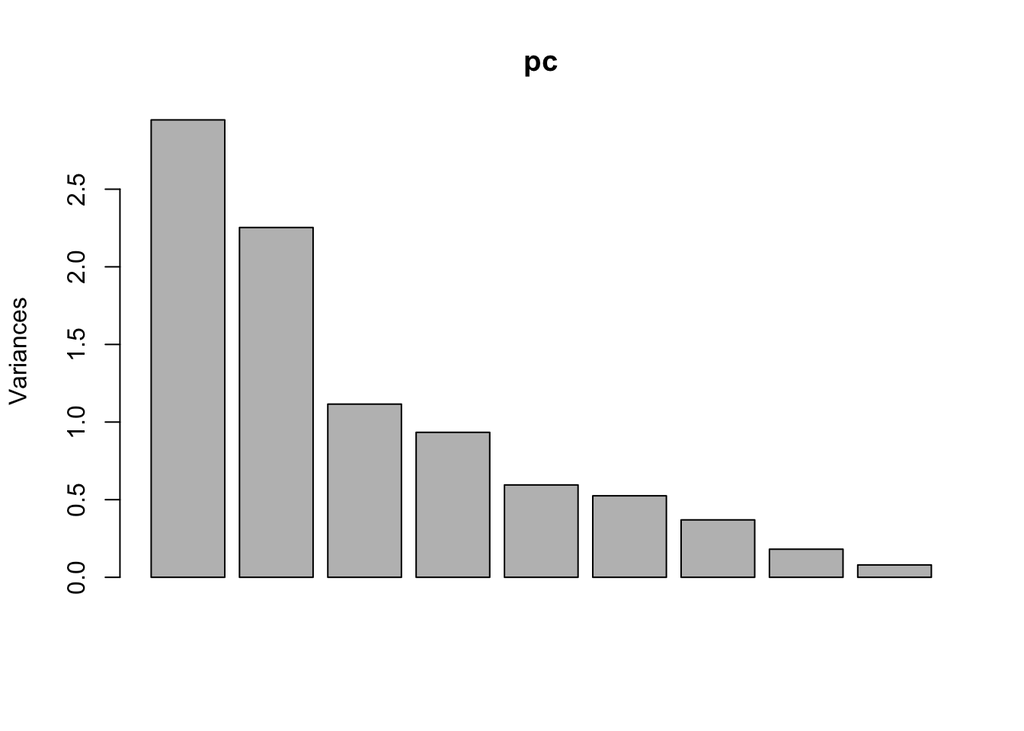

```r
plot(pc) # how many components do you want to include? No set answer
```

```r
pc # rotation section lets us know the relationship between IHC and principle components
```

```
## Standard deviations (1, .., p=9):
## [1] 1.7165314 1.5010904 1.0562385 0.9663162 0.7713738 0.7246112 0.6082358
## [8] 0.4255182 0.2823918
##
## Rotation (n x k) = (9 x 9):
##                    PC1        PC2         PC3        PC4         PC5
## SF1Median   0.42400202 -0.2711315 -0.12745729  0.1579344 -0.33075438
## Pit1Median -0.49077081 -0.2655414  0.10180787 -0.2530151 -0.09417432
## TPITMedian -0.08392066  0.6017129 -0.12046627 -0.2135815  0.01020031
## PRLMedian  -0.40230883 -0.1750858  0.50857222 -0.2713551  0.07611863
## GHMedian   -0.35692670 -0.2487659 -0.42213411 -0.1055862 -0.40800647
## TSHMedian  -0.24101764 -0.1435125 -0.70787458 -0.0227797  0.39954244
## LHMedian    0.32648989 -0.1830059 -0.06906836 -0.6228492 -0.40954996
## FSHMedian   0.33801445 -0.1863191 -0.02443208 -0.5308112  0.58063372
## ACTHMedian -0.06430897  0.5590848 -0.12482379 -0.3322957 -0.21181246
##                    PC6         PC7          PC8         PC9
## SF1Median   0.06744034 -0.68680612  0.339555461 -0.06763234
## Pit1Median  0.05506450 -0.13225771  0.034336853 -0.76398841
## TPITMedian  0.05689762  0.06127010  0.747053330 -0.07473734
## PRLMedian  -0.19565609 -0.34700383  0.194830537  0.52227131
## GHMedian    0.54441503  0.17038775  0.047826479  0.35664670
## TSHMedian  -0.46307079 -0.20039677  0.021201774  0.07093819
## LHMedian   -0.45707804  0.30017600  0.012362485  0.01707710
## FSHMedian   0.47585734 -0.07091811 -0.006523891 -0.00512940
## ACTHMedian  0.06868943 -0.47150155 -0.533425884  0.02911273
```

```r
predict(pc)
```

[output not shown]

[output cut: 283 more lines]

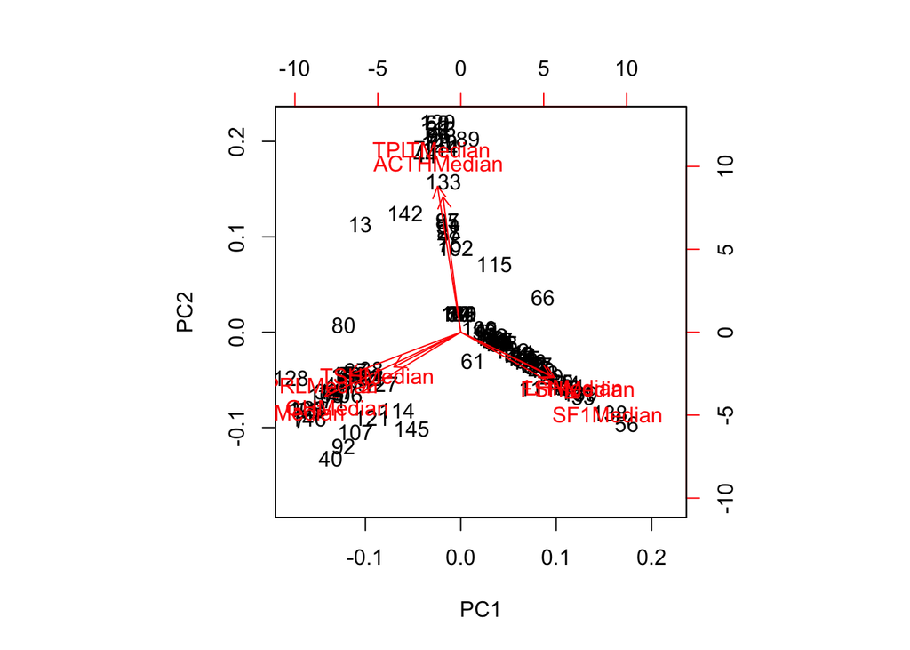

```r
biplot(pc) # VERY interesting in its ability to distinguish between the Pit1, SF1 and Tpit groups
```

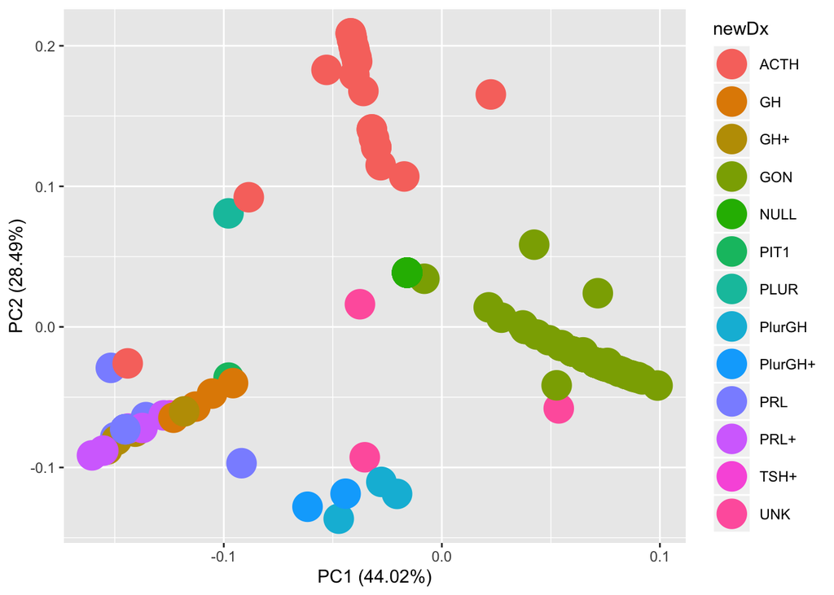

```r
library(ggfortify)
df <- patma %>%
  select(SF1Median, Pit1Median, TPITMedian, PRLMedian, GHMedian, TSHMedian, LHMedian, FSHMedian, ACTHMedian) %>%
  na.omit()

trimmedSet <- patma %>%
  select(SF1Median, Pit1Median, TPITMedian, PRLMedian, GHMedian, TSHMedian, LHMedian, FSHMedian, ACTHMedian, newDx) %>%
  na.omit()

autoplot(prcomp(df), data = trimmedSet, colour = 'newDx', size = 8)
```

## T-SNE (t-Distributed Stochastic Neighbor Embedding) analysis

This is an interesting method that is usually compared with PCA plots. See [this page](https://stackoverflow.com/questions/44837536/how-to-use-ggplot-to-plot-t-sne-clustering).

DataCamp has a tutorial for python that describes T-SNE at [this page](https://www.datacamp.com/community/tutorials/introduction-t-sne).

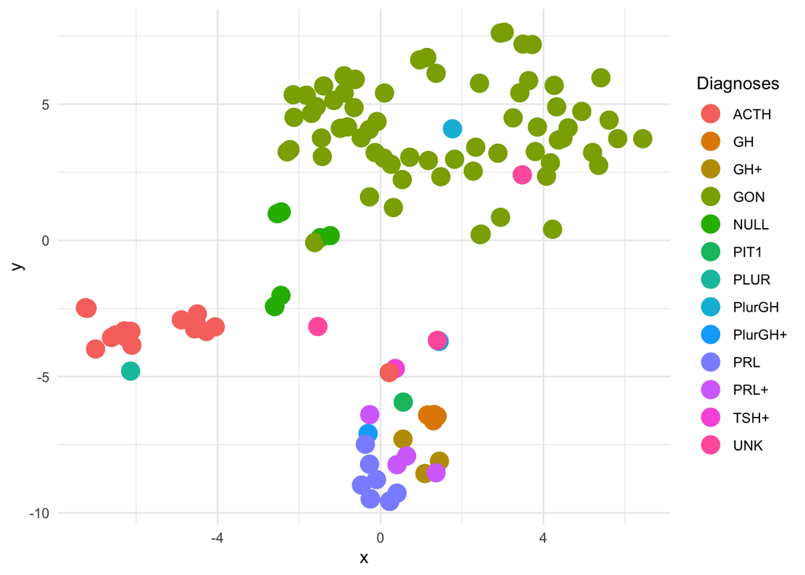

```r
library(Rtsne)
patma_unique <- patma %>%
  na.omit() %>%
  unique()
patma_matrix <- as.matrix(patma_unique[,c(4:12, 18, 23, 24)])
set.seed(2019)
tsne_out <- Rtsne(patma_matrix, check_duplicates = FALSE, theta = 0.0)

library(ggplot2)
tsne_plot <- data.frame(x = tsne_out$Y[,1], y = tsne_out$Y[,2], Diagnoses = patma_unique$newDx)

ggplot(tsne_plot) +
  geom_point(aes(x=x, y=y, color=Diagnoses), size = 5) +
  theme_minimal()
```

## K nearest neighbors supervised learning

This [R-blogger post](https://www.r-bloggers.com/k-nearest-neighbor-step-by-step-tutorial/) by Deepanshu Bhalla is a pretty clean introduction to KNN, and does a nice job distinguishing it from K-means analysis, which is often confused with it. [This demo](http://rpubs.com/Nitika/kNN_Iris) also has some nice advice.

Remember than KNN is a supervised method and that K-means is unsupervised.

## Classification trees

This [webpage](http://www.sthda.com/english/articles/35-statistical-machine-learning-essentials/141-cart-model-decision-tree-essentials/) has a nice discussion of CART analyses.

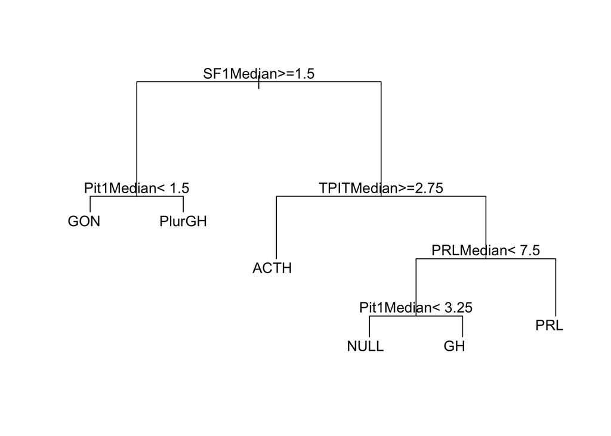

```r
library(rpart)
trimmedSet <- patma %>%
  select(SF1Median, Pit1Median, TPITMedian, PRLMedian, GHMedian, TSHMedian, LHMedian, FSHMedian, ACTHMedian, newDx) %>%
  na.omit()

model <- rpart(newDx ~., data = trimmedSet)
par(xpd = NA) # otherwise on some devices the text is clipped
plot(model)
text(model, digits = 3)
```

# The Foundation of Practical Pituitary Adenoma Diagnosis: The Role of Tpit Immunohistochemistry

Pituitary adenoma classification suffers from a variety of problems. Initially developed with electron microscopy in mind, the World Health Organization classification retains many of the vestiges of those early studies and their problems: reliance on small numbers of experts sampling miniscule portions of variably sampled tumors, with the most important series apparently jumping primary literature for publication in textbooks.

The effect was to establish a classification that has been difficult to refine, even with the advent of new IHC for transcription factors. Substantive arguments about prevalence and classification are avoided in favor of unimportant nomenclature changes (pituitary neuroendocrine tumor or PitNET is neither more brief nor more useful than its precursor, but it enjoys the praise of endocrine pathologists, and it sounds clever. Cleverness notwithstanding, it fails to clarify the fundamental problem of classification.

We published a series of 136 PitNETs in 2017 in an attempt to improve the situation. At the time, reagents suitable for formalin-fixed, paraffin-embedded material were available for only Steroidogenic Factor 1 and Pit-1. Nonetheless, we were able to show great improvements, both in terms of diagnostic efficiency and diagnostic accuracy, with the use of these stains, and related a simple algorithm that was sufficient to diagnose most PitNETs with three IHC stains.

Pituitary adenomas can be classified in three broad families based on their resemblance to developmental pathways of the anterior pituitary (1). While immunohistochemical stains for the six anterior pituitary hormones (prolactin, growth hormone, thyroid stimulating hormone, luteinizing hormone, follicle stimulating hormone and adrenocorticotropin (ACTH)) are widely used, some of these suffer from suboptimal sensitivity and specificity. ACTH immunoreactivity in particular is widely regarded as lacking in sensitivity and specificity. This is problematic, since ACTH-producing macroadenomas are considered more aggressive(2), and the resection of hormonally active ACTH-producing tumors can cause life-threatening cortisol insufficiency if left untreated. That is, both over- and under-detection of ACTH-producing tumors can have clinical consequences.

ACTH-producing adenomas account for approximately 17% of pituitary adenomas (3) . T-box transcription factor (T-Pit) mediates the corticotroph pathway (4, 5). Until recently, immunostains for T-Pit were restricted to frozen material, but the introduction of a polyclonal antibody to T-pit developed and validated according to standardized procedures within the Human Protein Atlas (http://www.proteinatlas.org) provides a reagent that reportedly overcomes this restriction.

In this work, we use T-Pit IHC in conjunction with IHC for SF-1 and Pit-1 to classify pituitary adenomas. According to Sjostedt et al. (6), T-Pit IHC is more sensitive and specific than ACTH IHC.